# Stack_Overflow_Questions_Forecasting

Ritik Kumar

2024-11-24

## Importing the dataset

```r
library(fpp)
library(fpp2)
library(readxl)
```

```r
library(forecast)
library(ggplot2)
library(dplyr)
#Import the dataset
data <- read_excel("C:/Users/malho/Downloads/TotalQuestions_Stack_Overflow.xlsx")
print(head(data))
```

```
## # A tibble: 6 × 21
##   Month  `C++`  `C#` TypeScript   PHP Swift  Ruby    Go   SQL Kotlin Scala Shell
##   <chr>  <dbl> <dbl>      <dbl> <dbl> <dbl> <dbl> <dbl> <dbl>  <dbl> <dbl> <dbl>
## 1 2008-…   755  1639          0   474     0   286     0   503      0     6    65
## 2 2008-…   734  1729          0   499     0   157     0   413      0     5    51
## 3 2008-…   630  1594          0   476     0   159     0   424      0     3    51
## 4 2009-…   848  2374          0   628     1   205     0   585      0    12    47
## 5 2009-…   841  2597          0   757     1   286     0   668      0    12    75
## 6 2009-…  1046  3155          0   895     1   329     0   658      0    17    85
## # ℹ 9 more variables: C <dbl>, HTML <dbl>, `Objective-C` <dbl>, Perl <dbl>,
## #   Matlab <dbl>, R <dbl>, Python <dbl>, Java <dbl>, Javascript <dbl>
```

- First we import the dataset and print the head of data to see our data must be succesfully uploaded or not.

## Forcasting of Python questions by using Stack Overflow Dataset

##### Creating Times Series Plot

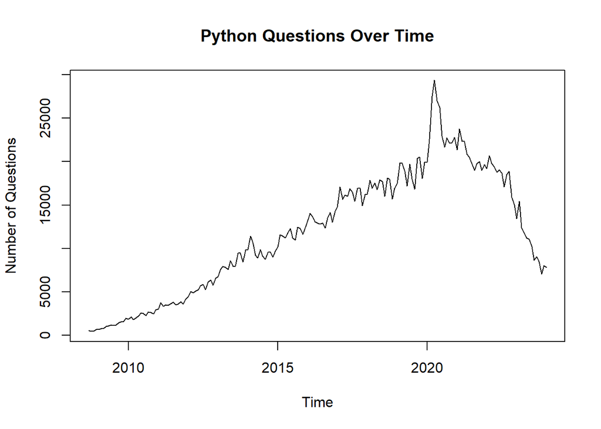

```r
# first Convert 'Month' column to Date type
data$Month <- as.Date(data$Month, format = "%m/%d/%Y")

# Convert it into Time Series data
python_ts <- ts(data$Python, start = c(2008,9), frequency = 12)

# Plot the original time series data of Python Question from 2008-2022
plot(python_ts, main = "Python Questions Over Time", xlab = "Time", ylab = "Number of Questions")
```

##### Initial Observations

- From all programming languages questions we are going to forecast the python related questions by using the dataset.
- In the second step we convert the month column to data type to better use the column for the forecasting models.
- Convert the python data into time series data format to forecast the data.
- We start with plotting the time series to visualize and understand the data.
- The plot shows that there is an increasing trend in the python questions starting from 2008 till around 2021.
- From 2021 till 2024, there has been observed a decreasing trend in the python questions.
- If we were to forecast the data, we should be considering the window from 2018.

## Considering only a window from 2018 to 2024

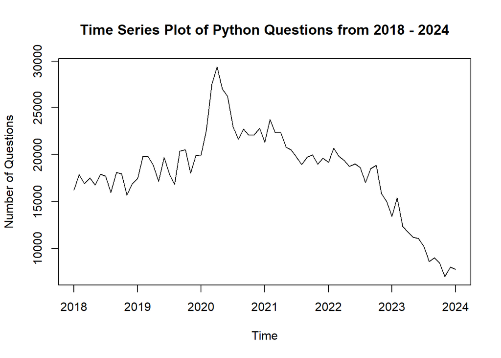

```r
python_ts_actual <- window(python_ts, start = 2018, end = 2024 )
plot(python_ts_actual, main = "Time Series Plot of Python Questions from 2018 - 2024", xlab = "Time", ylab = "Number of Questions")
```

## Identify Central Tendency

##### Min, max, mean, median, 1st and 3rd Quartile values of the times series

```r
summary(python_ts_actual)
```

```
##    Min. 1st Qu.  Median    Mean 3rd Qu.    Max.
##    7028   16778   18874   18134   20536   29378
```

- The summary function above gives the min, max, mean, median, 1st and 3rd Quartile values of the times series.

##### Box Plot

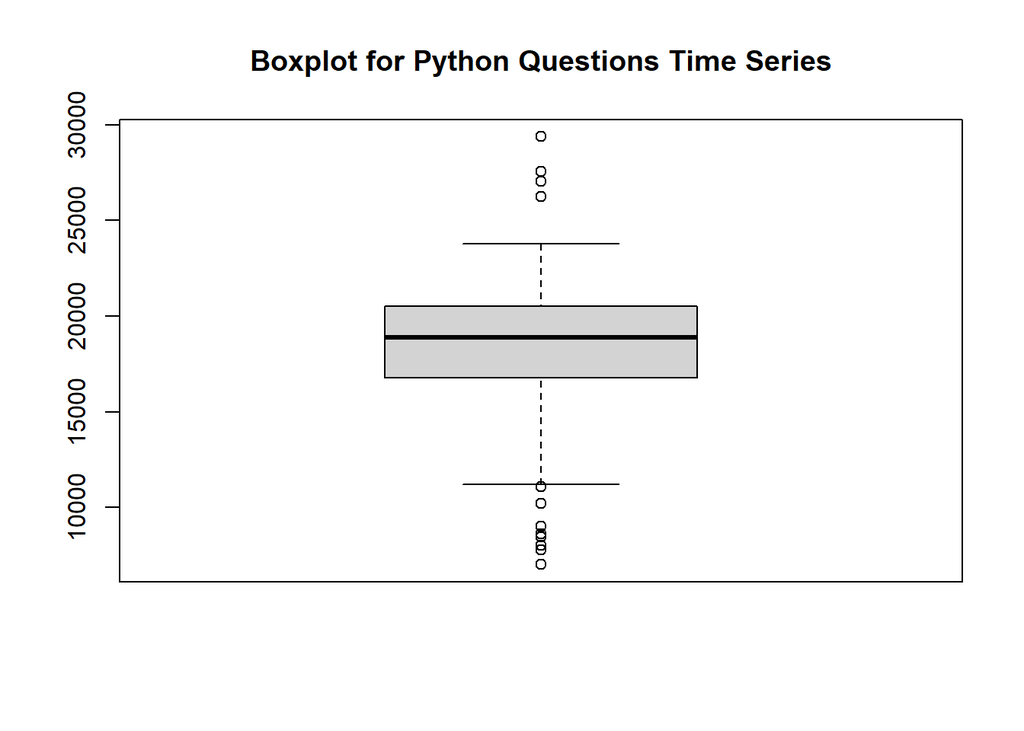

```r
boxplot(python_ts_actual, main ='Boxplot for Python Questions Time Series')
```

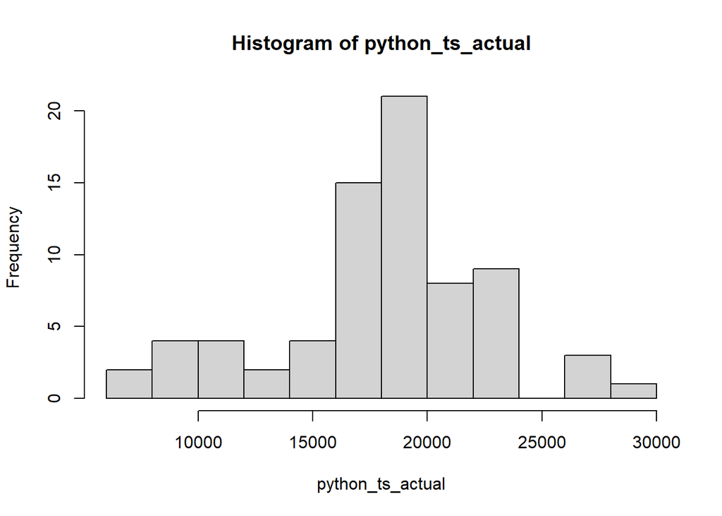

```r
hist(python_ts_actual)
```

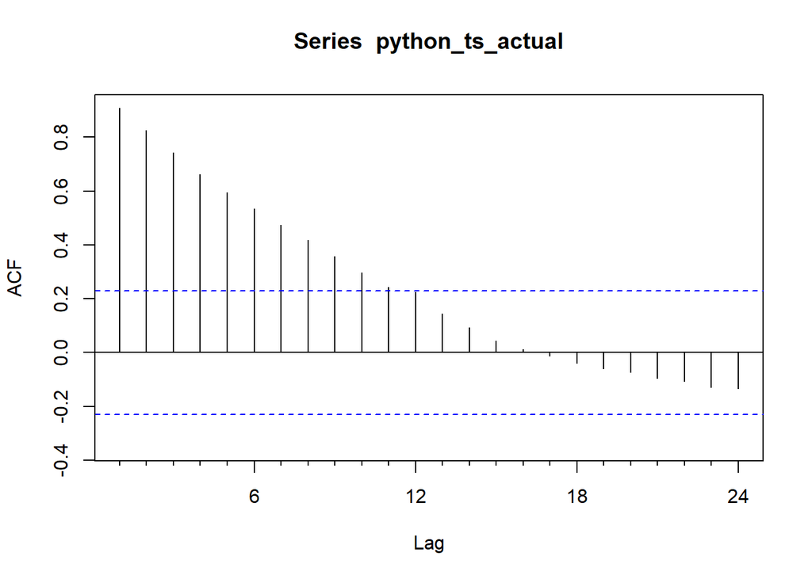

```r
Acf(python_ts_actual)
```

##### Observations and Inferences

- The boxplot shows that there are few outliers in the data that present on both the upper and lower ends, indicating rare or extreme values.
- From summary, we can also see that the mean value is less then the median value for the time series.
- The plot appears slightly symmetrical rather than strongly left-skewed, as the box and whiskers are somewhat balanced.
- The presence of lower outliers might give an impression of left skewness, but it would need confirmation using statistical skewness metrics.
- Most data points lie within a consistent range, with a moderate interquartile range(IQR)
- From the ACF plot, we can see that many of the values crossed the confidence intervals, stating there is a trend component in the data.
- Also, we can see that after 16th lag period, the ACF plot is dipping into the negative values stating seasonality also exists in the data.

## Decomposition

##### Decomposition Plot

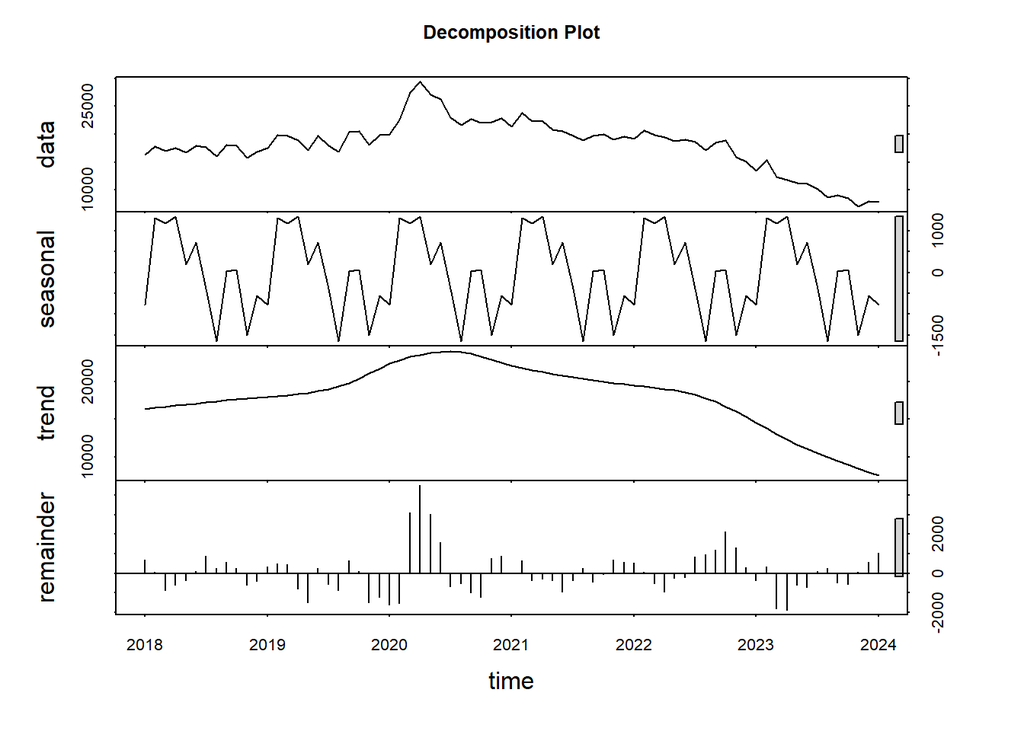

```r
stl_decomp <- stl(python_ts_actual, s.window = "periodic")
plot(stl_decomp, main = 'Decomposition Plot')
```

##### Is the time series seasonal?

- Yes, The time series is seasonal, as evident from the consistent repeating pattern in the seasonal component.

##### Is the decomposition additive or multiplicative?

```r
decom <- decompose(python_ts_actual)
decom$type
```

```
## [1] "additive"
```

- The decomposition seems to be additive.
- Because, with as trend increases, we do not see any increase in the seasonality. The seasonality appears to be the same repeated throughout.

##### • If seasonal, what are the values of the seasonal monthly indices?

```r
decom$figure
```

```
##  [1] -1056.7377  1238.7706  1287.6789  1406.0623   218.7789   675.0123
##  [7]  -396.4683 -1706.9711   145.7289   226.9456 -1430.5461  -608.2544
```

- In time series decomposition, decom$figure refers to the seasonal component values extracted during the decomposition process in R.
- It shows how much the seasonal component contributes to or detracts from the overall value for each time point in a single cycle.
- Positive values indicate the time point contributes above average to the data.
- Negative values indicate it contributes below average to the data.

##### Seasonality adjusted plot

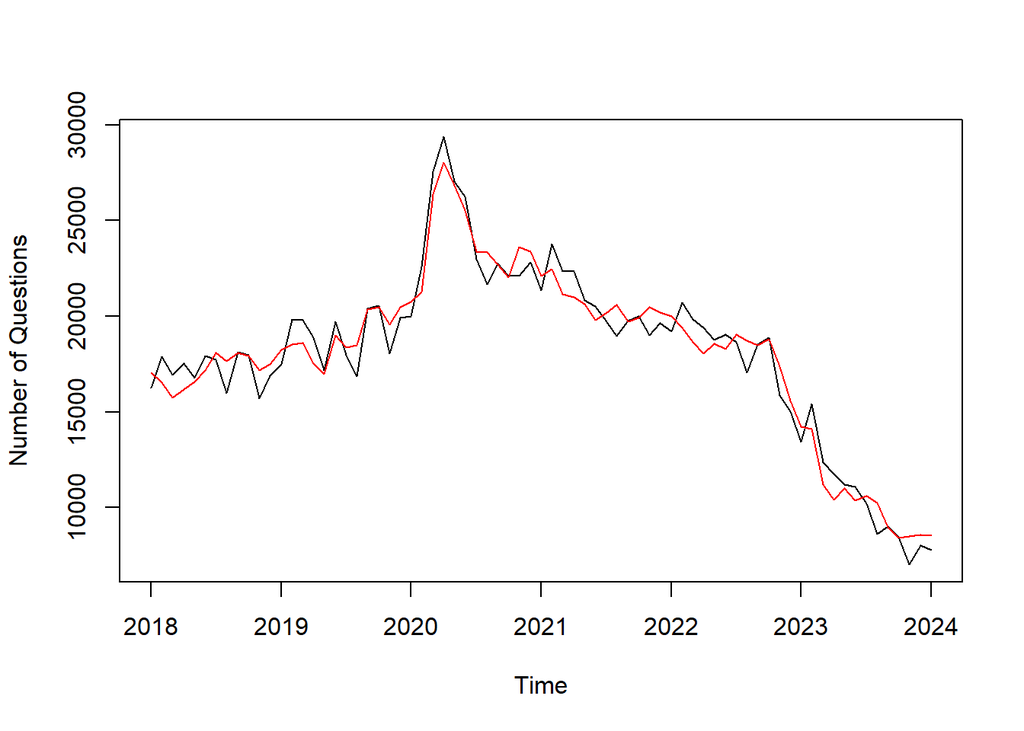

```r
plot(python_ts_actual, ylab = 'Number of Questions')
lines(seasadj(stl_decomp), col="Red")
```

- There are repeated fluctuations that can be observed after applying seasonal adjustment.
- With time, these fluctuations will cause deviations and change our forecast. So, it is important to consider the seasonal variation in the data.

## Testing the various Forecasting methods for the given dataset

## Naive Method

- The naive forecasting method is one of the simplest forecasting techniques. It assumes that the most recent observed value is the best predictor for all future values. This method does not account for trends, seasonality, or other patterns in the data.

##### Output

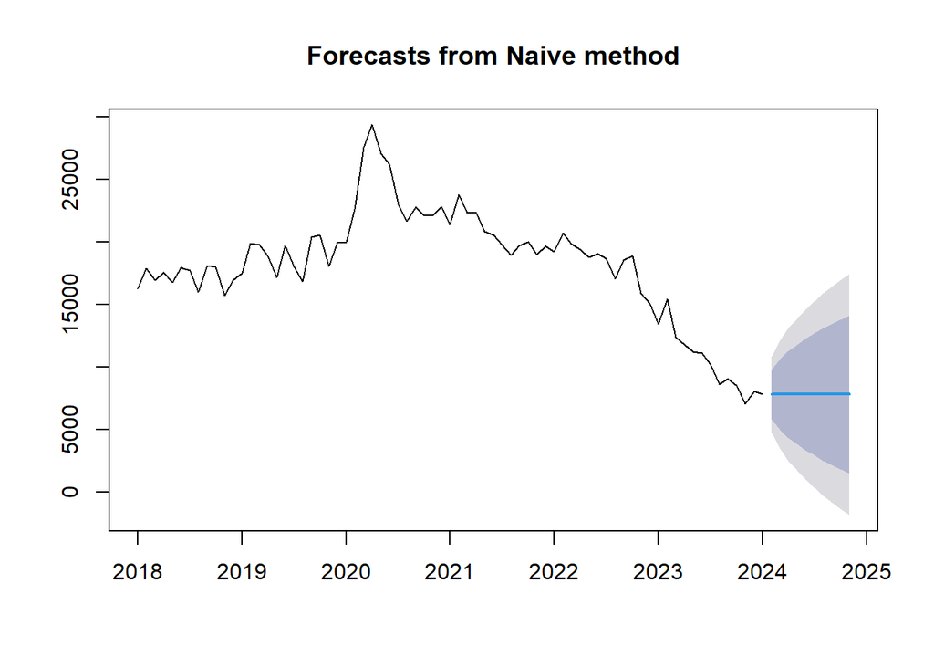

```r
naive_forecast <- naive(python_ts_actual)
plot(naive_forecast)
```

##### Perform Residual Analysis for this technique.

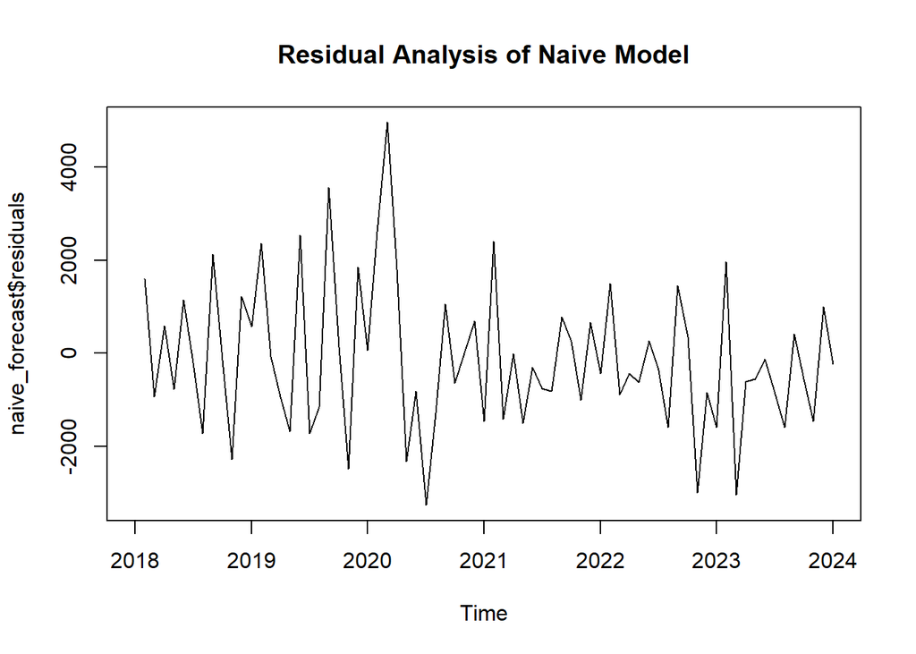

```r
plot(naive_forecast$residuals, main = "Residual Analysis of Naive Model")
```

###### Residuals Histogram

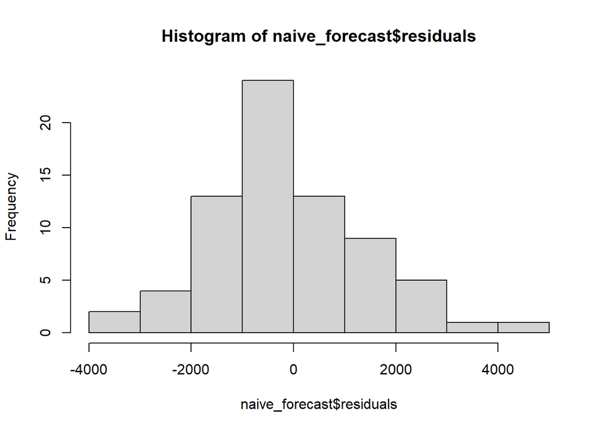

```r
hist(naive_forecast$residuals)
```

- The histogram appears roughly symmetrical around 0, indicating that the residuals are balanced, with no significant skewness in the errors.
- The residuals resemble a bell-shaped distribution but require a Q-Q plot or test for confirmation.
- Most residuals lie within ±2000, suggesting good accuracy, though a few outliers exist beyond ±3000.
- Extreme values indicate potential anomalies or areas for model refinement.

###### Fitted vs Residual Values

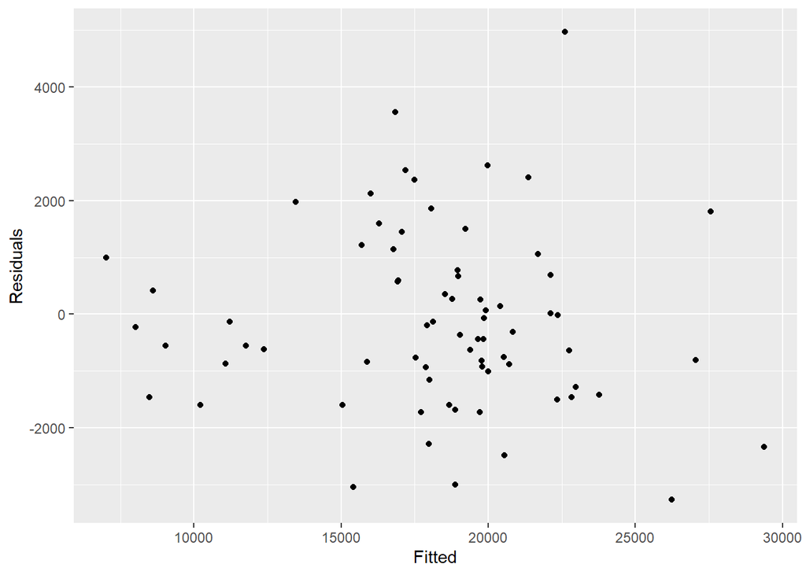

```r
cbind(Fitted = fitted(naive_forecast),
      Residuals = residuals(naive_forecast)) %>%
  as.data.frame() %>%
  ggplot( aes(x= Fitted, y= Residuals)) + geom_point()
```

- The residuals are scattered randomly around zero, indicating no clear patterns or systematic errors.
- The spread of residuals appears relatively consistent, with no obvious funneling or widening patterns, suggesting constant variance.
- A few residuals deviate significantly, indicating potential outliers that might need further investigation.
- The lack of visible patterns supports that the model fits the data reasonably well.

###### Actual vs Residual values

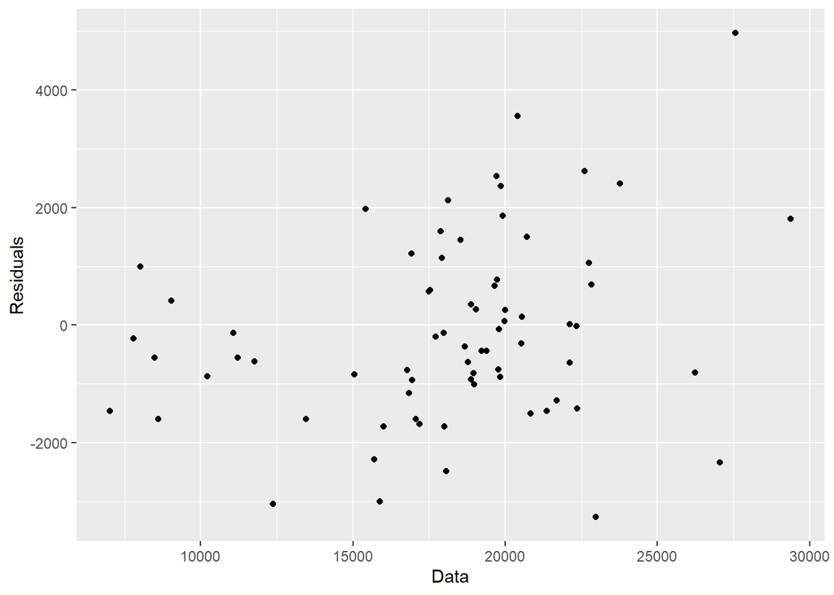

```r
cbind(Data=python_ts_actual,
      Residuals=residuals(naive_forecast)) %>%
  as.data.frame() %>%
  ggplot(aes(x=Data, y=Residuals)) + geom_point()
```

###### ACF of residuals

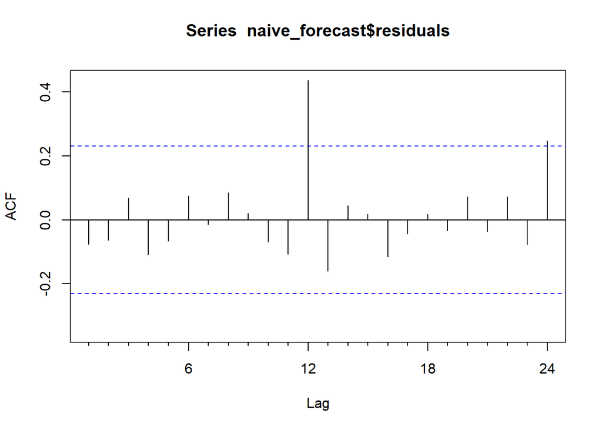

```r
Acf(naive_forecast$residuals)
```

- A significant spike is observed at lag 12, indicating potential seasonality that has not been fully captured by the model.
- Most other lags fall within the confidence bounds, suggesting that residuals are largely uncorrelated.
- The presence of significant autocorrelation at lag 12 suggests the model may not have fully accounted for seasonal patterns.

##### Accuracy

```r
accuracy(naive_forecast)
```

```
##                     ME    RMSE      MAE       MPE     MAPE      MASE
## Training set -117.9167 1559.15 1228.333 -1.411541 7.070555 0.2962812
##                     ACF1
## Training set -0.07556797
```

##### Forecast

```r
forecast(naive_forecast)
```

```
##          Point Forecast    Lo 80     Hi 80      Lo 95    Hi 95
## Feb 2024           7793 5794.869  9791.131  4737.1231 10848.88
## Mar 2024           7793 4967.217 10618.783  3471.3374 12114.66
## Apr 2024           7793 4332.136 11253.864  2500.0659 13085.93
## May 2024           7793 3796.739 11789.261  1681.2461 13904.75
## Jun 2024           7793 3325.044 12260.956   959.8514 14626.15
## Jul 2024           7793 2898.600 12687.400   307.6608 15278.34
## Aug 2024           7793 2506.444 13079.556  -292.0904 15878.09
## Sep 2024           7793 2141.433 13444.567  -850.3252 16436.33
## Oct 2024           7793 1798.608 13787.392 -1374.6308 16960.63
## Nov 2024           7793 1474.356 14111.644 -1870.5314 17456.53
```

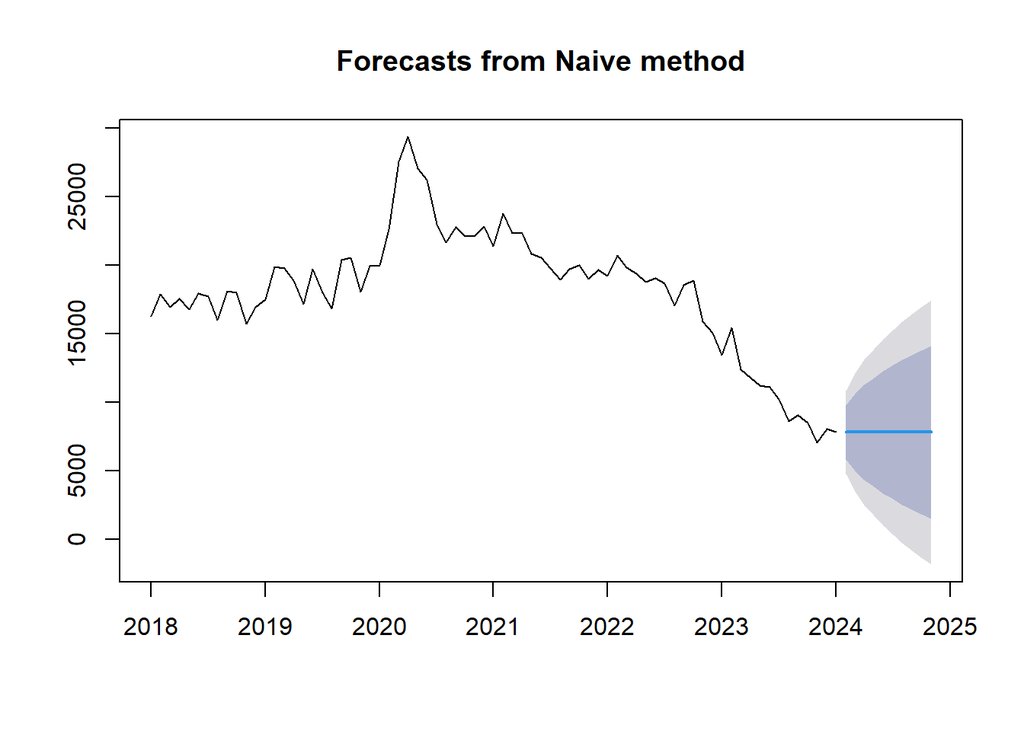

```r
plot(forecast(naive_forecast))
```

## Simple Moving Averages

- Simple Moving Averages (SMA) is a basic yet widely used time-series forecasting method. It calculates the average of a fixed number of past observations, updating the average as new data becomes available.

##### Plot the graph for time series.

##### Simple Moving average of order 3, 6, and 9

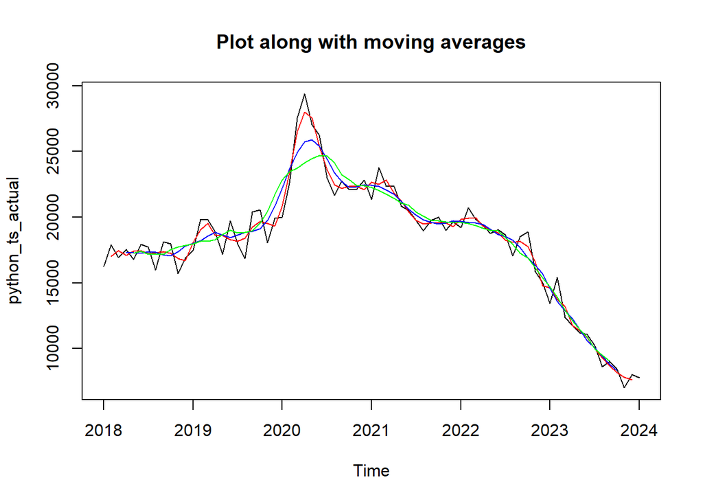

```r
ma3_forecast = ma(python_ts_actual, order = 3)
ma6_forecast = ma(python_ts_actual, order = 6)
ma9_forecast = ma(python_ts_actual, order = 9)
plot(python_ts_actual, main ="Plot along with moving averages")
lines(ma3_forecast, col='Red')
lines(ma6_forecast, col='Blue')
lines(ma9_forecast, col='Green')
```

##### Observations

- The plot shows the original time series (python_ts_actual) along with multiple moving averages of different window sizes.
- From the plots, it is observed that the higher the order we consider, the smoother the moving average curve in the plot.
- It can be seen that the Green line above is the smoothest compared to Blue or Red lines.
- The black line (original data) exhibits sharp fluctuations, which are smoothed out by the moving averages, making it easier to discern overall trends.
- The Red line (order 3) gives the most real data compared to the other two. The higher order averages smoother the plot and do not give the actual values.

## Simple Smoothing

- Simple Smoothing, also known as Simple Exponential Smoothing (SES), is a forecasting method used for time-series data. It is designed to handle data without trends or seasonality by giving exponentially decreasing weights to past observations, with more weight assigned to recent data points.

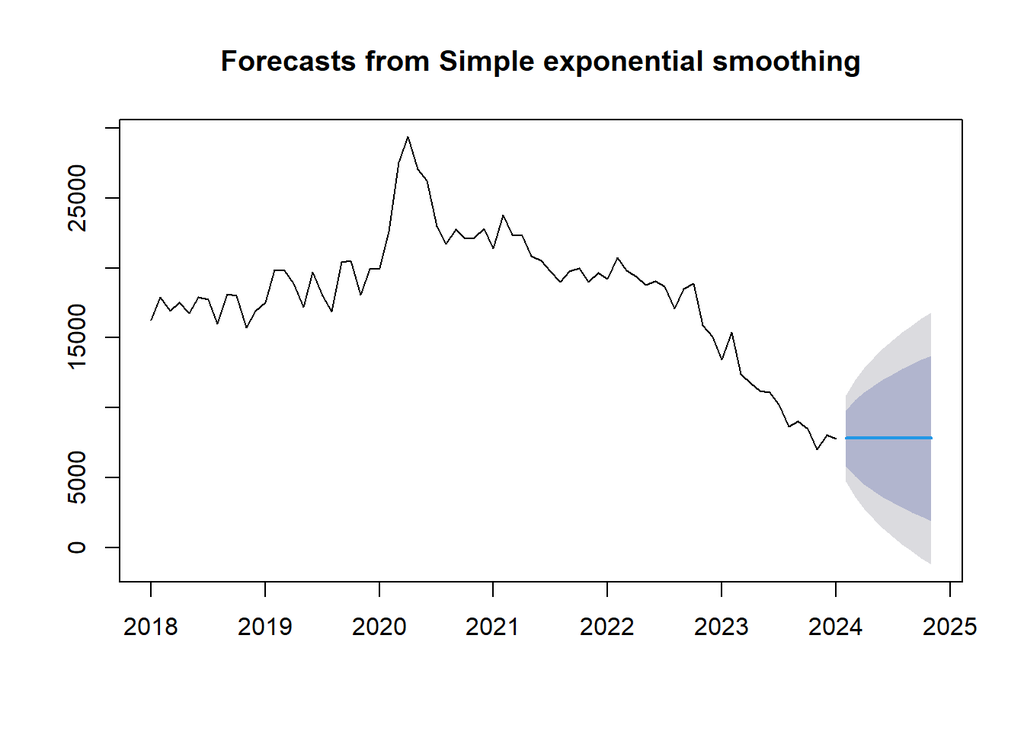

```r
ses_data = ses(python_ts_actual)
plot(ses_data)
```

```r
attributes(ses_data)
```

```
## $names
##  [1] "model"     "mean"      "level"     "x"         "upper"     "lower"
##  [7] "fitted"    "method"    "series"    "residuals"
##
## $class
## [1] "forecast"
```

```r
summary(ses_data)
```

```
##
## Forecast method: Simple exponential smoothing
##
## Model Information:
## Simple exponential smoothing
##
## Call:
## ses(y = python_ts_actual)
##
##   Smoothing parameters:
##     alpha = 0.9228
##
##   Initial states:
##     l = 16401.1605
##
##   sigma:  1565.908
##
##      AIC     AICc      BIC
## 1391.184 1391.532 1398.055
##
## Error measures:
##                     ME     RMSE      MAE       MPE     MAPE      MASE
## Training set -127.6003 1544.308 1212.348 -1.507883 6.957486 0.2924254
##                      ACF1
## Training set -0.003297389
##
## Forecasts:
##          Point Forecast    Lo 80     Hi 80      Lo 95    Hi 95
## Feb 2024       7805.586 5798.795  9812.378  4736.4633 10874.71
## Mar 2024       7805.586 5074.925 10536.248  3629.3999 11981.77
## Apr 2024       7805.586 4506.221 11104.952  2759.6425 12851.53
## May 2024       7805.586 4022.055 11589.118  2019.1741 13592.00
## Jun 2024       7805.586 3593.175 12017.998  1363.2589 14247.91
## Jul 2024       7805.586 3204.096 12407.077   768.2146 14842.96
## Aug 2024       7805.586 2845.444 12765.729   219.7036 15391.47
## Sep 2024       7805.586 2511.032 13100.141  -291.7363 15902.91
## Oct 2024       7805.586 2196.521 13414.651  -772.7382 16383.91
## Nov 2024       7805.586 1898.734 13712.439 -1228.1653 16839.34
```

##### Residual Analysis

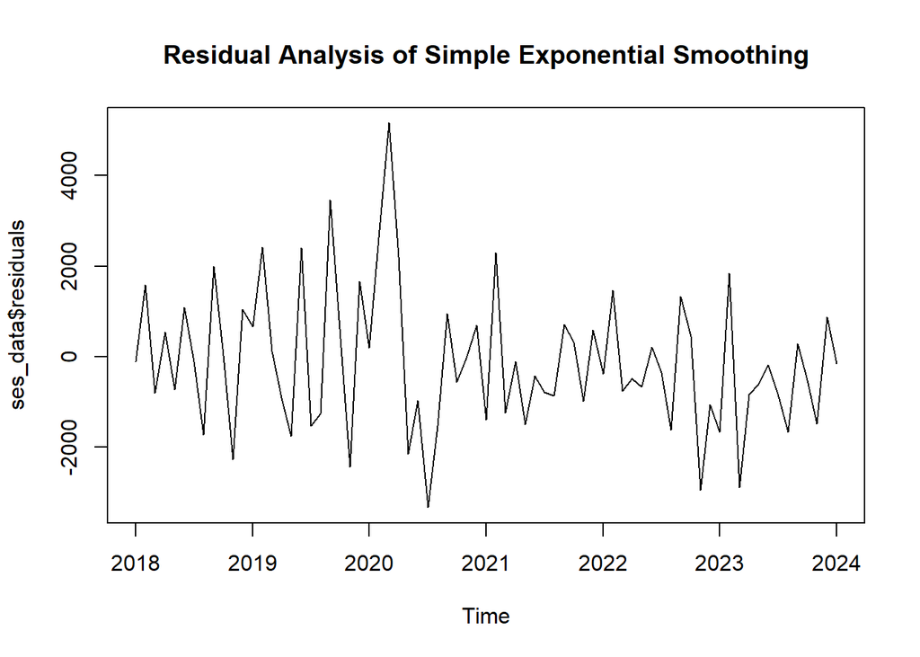

```r
plot(ses_data$residuals, main = "Residual Analysis of Simple Exponential Smoothing")
```

- The residuals show no clear pattern over time, indicating the model captures the main structure of the data.
- The spread of residuals appears consistent, though there are a few spikes (e.g., around 2020) suggesting occasional large errors.
- Residuals oscillate around zero, implying minimal bias in predictions.
- Large positive and negative deviations indicate periods where the model struggled to fit the data accurately.

###### Histogram plot of residuals

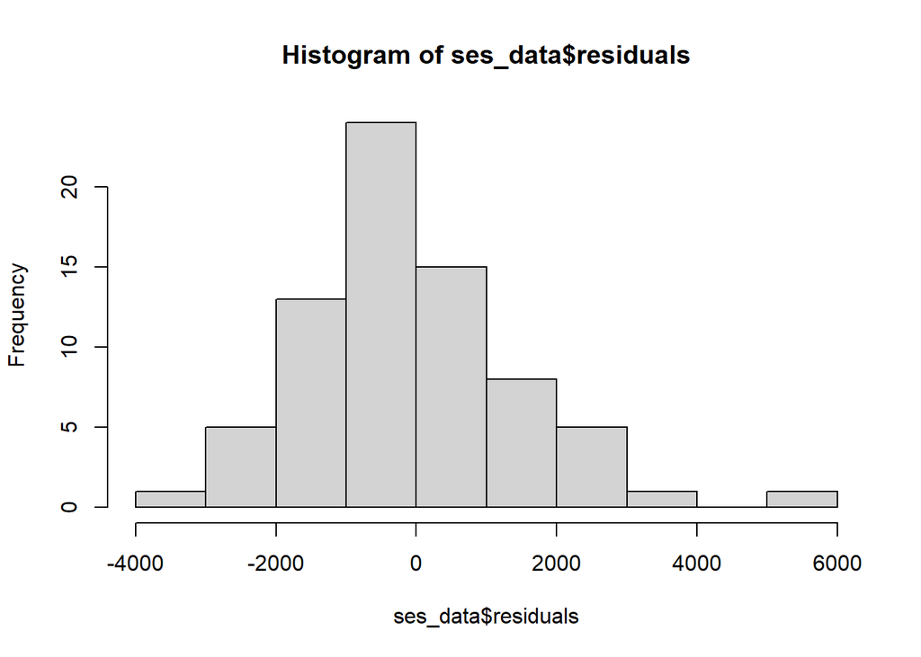

```r
hist(ses_data$residuals)
```

- The histogram is approximately symmetric around zero, suggesting minimal bias in the model’s predictions.
- The residuals resemble a normal distribution, though there may be some deviation at the tails.
- Most residuals are concentrated near zero, indicating that the model performs well on average.
- A few residuals extend beyond ±4000, suggesting occasional large prediction errors.

###### Fitted values vs. residuals

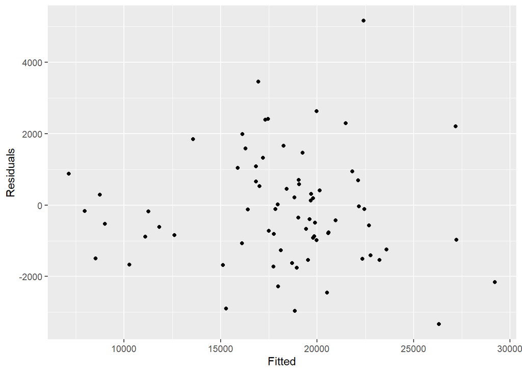

```r
cbind(Fitted=fitted(ses_data),
      Residuals=residuals(ses_data)) %>%
  as.data.frame() %>%
  ggplot(aes(x=Fitted,y=Residuals)) + geom_point()
```

- Residuals are randomly scattered around zero, indicating no visible patterns and supporting the assumption of a well-fitted model.
- The residuals show no trend or structure, suggesting that the model does not systematically over predict or under predict across fitted values.
- The spread of residuals appears relatively consistent across the range of fitted values, indicating homoscedasticity (constant variance).
- A few residuals deviate significantly from zero, indicating potential outliers or instances where the model struggled.

###### Actual values vs. residuals

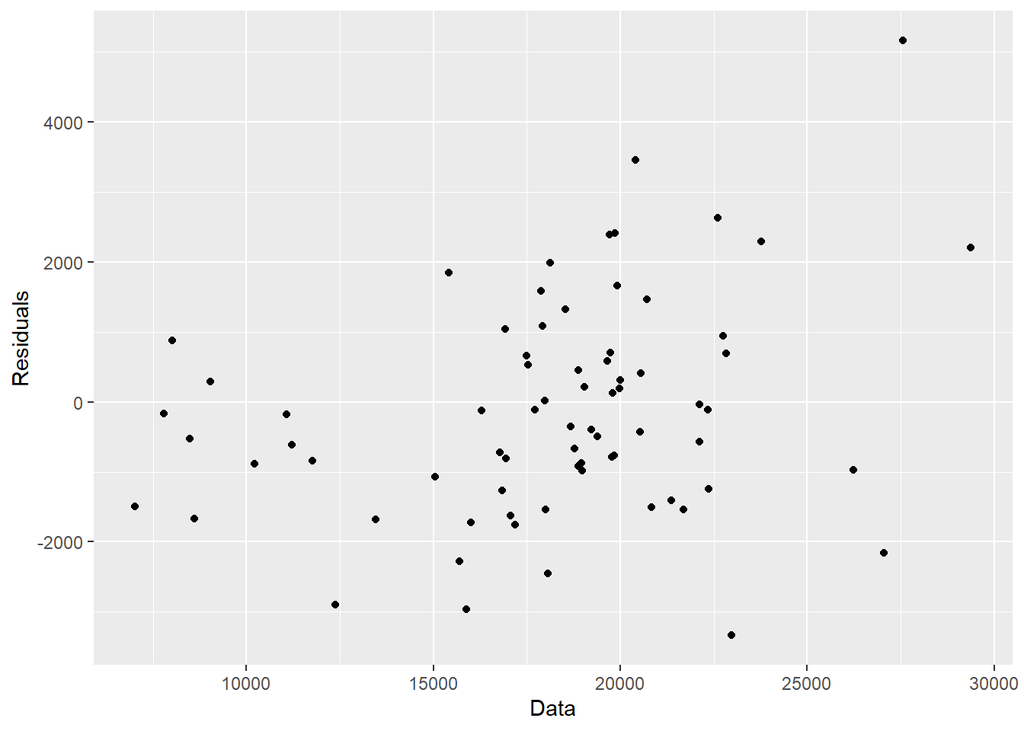

```r
cbind(Data = python_ts_actual,
      Residuals=residuals(ses_data)) %>%
  as.data.frame() %>%
  ggplot(aes(x=Data, y=Residuals)) + geom_point()
```

###### ACF plot of the residuals

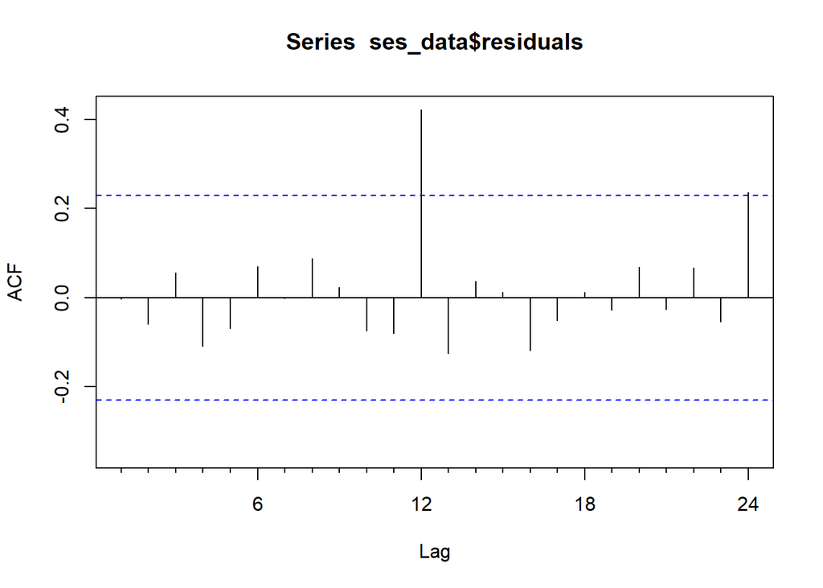

```r
Acf(ses_data$residuals)
```

- A significant spike at lag 12 indicates potential seasonality that has not been fully captured by the model.
- Residual auto correlations at other lags are mostly within the confidence intervals, suggesting that most of the residuals are uncorrelated.
- The significant seasonal autocorrelation at lag 12 suggests that the simple exponential smoothing (SES) model is not effectively capturing the seasonality in the data.
- We will use a seasonal model (e.g., Holt-Winters or SARIMA) to address the seasonal pattern evident at lag 12.

##### Accuracy

```r
accuracy(ses_data)
```

```
##                     ME     RMSE      MAE       MPE     MAPE      MASE
## Training set -127.6003 1544.308 1212.348 -1.507883 6.957486 0.2924254
##                      ACF1
## Training set -0.003297389
```

##### Forecast

```r
ses_data
```

```
##          Point Forecast    Lo 80     Hi 80      Lo 95    Hi 95
## Feb 2024       7805.586 5798.795  9812.378  4736.4633 10874.71
## Mar 2024       7805.586 5074.925 10536.248  3629.3999 11981.77
## Apr 2024       7805.586 4506.221 11104.952  2759.6425 12851.53
## May 2024       7805.586 4022.055 11589.118  2019.1741 13592.00
## Jun 2024       7805.586 3593.175 12017.998  1363.2589 14247.91
## Jul 2024       7805.586 3204.096 12407.077   768.2146 14842.96
## Aug 2024       7805.586 2845.444 12765.729   219.7036 15391.47
## Sep 2024       7805.586 2511.032 13100.141  -291.7363 15902.91
## Oct 2024       7805.586 2196.521 13414.651  -772.7382 16383.91
## Nov 2024       7805.586 1898.734 13712.439 -1228.1653 16839.34
```

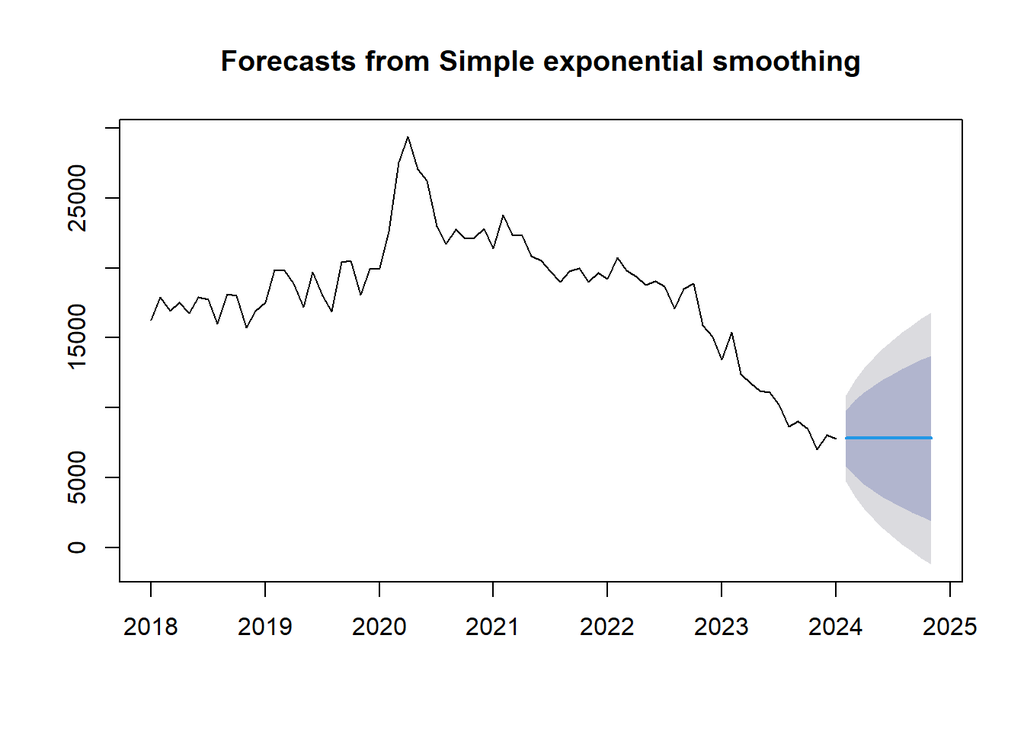

```r
plot(ses_data)
```

##### Simple Smoothing Summary

- The forecasted values remain constant, reflecting the characteristic of simple exponential smoothing, which assumes no trend or seasonality.
- Prediction intervals (shaded regions) widen over time, indicating increasing uncertainty as the forecast horizon extends.
- The model captures historical fluctuations to some extent, but the constant forecast suggests it does not account for recent downward trends.
- The lack of trend or seasonality in the forecast highlights the model’s inability to handle more complex patterns in the data.
- The SES model performs well for data without trends or seasonality, but negative lower bounds suggest limitations in handling the data’s variability. For better accuracy, consider trend or seasonal models like Holt or Holt-Winters.

## Holt-Winters

- The Holt-Winters Method, also known as Triple Exponential Smoothing, is a powerful forecasting technique for time-series data that incorporates trend and seasonality components in addition to the level of the data. It extends the simpler exponential smoothing methods by accounting for data patterns that change over time.

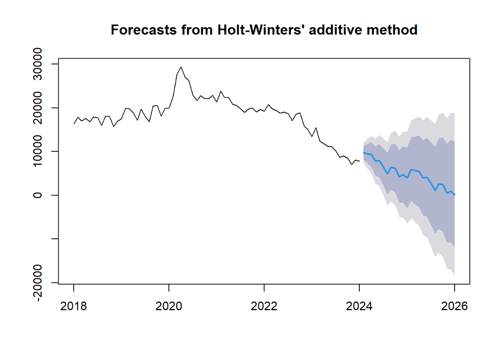

```r
Hw_forecast <- hw(python_ts_actual, seasonal = "additive")
plot(forecast(Hw_forecast))
```

```r
attributes(Hw_forecast)
```

```
## $names
##  [1] "model"     "mean"      "level"     "x"         "upper"     "lower"
##  [7] "fitted"    "method"    "series"    "residuals"
##
## $class
## [1] "forecast"
```

```r
Hw_add <- forecast(Hw_forecast)
```

- Here, additive Holt winters method is considered.
- The model captures both the declining trend and seasonal patterns in the data, as seen in the smooth downward-sloping forecast.
- Prediction intervals widen over time, indicating increasing uncertainty as the forecast horizon extends.
- The consistent amplitude of seasonal fluctuations suggests the data’s seasonal effects are additive (constant over time).
- Lower bounds of the forecast interval dip into negative values, which may be unrealistic for the given data context.
- The model effectively captures the data’s structure, but consider evaluating whether negative forecasts are meaningful or if adjustments are required.

###### Observations

```r
Hw_add$model
```

```
## Holt-Winters' additive method
##
## Call:
## hw(y = python_ts_actual, seasonal = "additive")
##
##   Smoothing parameters:
##     alpha = 0.9999
##     beta  = 0.0495
##     gamma = 1e-04
##
##   Initial states:
##     l = 17754.3854
##     b = 150.9935
##     s = -608.1393 -1430.284 227.215 146.2024 -1706.902 -396.51
##            674.9424 218.6703 1405.956 1287.234 1238.242 -1056.626
##
##   sigma:  1206.415
##
##      AIC     AICc      BIC
## 1365.072 1376.200 1404.010
```

##### Residual Analysis

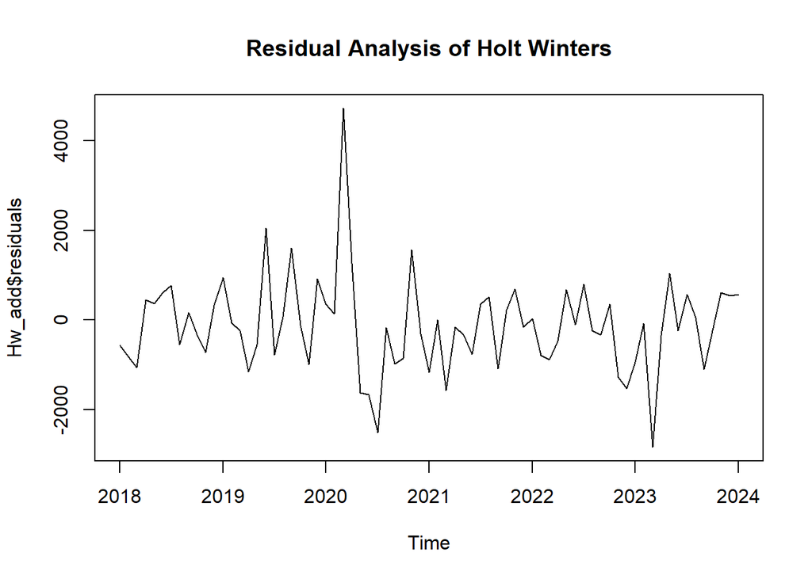

```r
plot(Hw_add$residuals, main = "Residual Analysis of Holt Winters")
```

- The residuals fluctuate randomly around zero, indicating that the model captures most of the patterns in the data.
- A significant spike and dip around 2020 suggest the presence of outliers or events that the model struggled to capture.
- Residuals generally exhibit consistent variability over time, supporting the assumption of homoscedasticity.
- Despite capturing trends and seasonality, the spikes indicate instances where the model’s performance was less accurate.
- We can observe a couple of up and downs throughout. But even they did not show and growing residual pattern.